# W3cubDocs

/Qt

# ChromaticAberration QML Type

A chromatic aberration effect. More...

| Import Statement: | import QtQuick3D.Effects |
| --- | --- |

- [List of all members, including inherited members](https://doc.qt.io/qt-6.2/qml-qtquick3d-effects-chromaticaberration-members.html)

## Properties

- **aberrationAmount** : real
- **focusDepth** : real
- **maskTexture** : TextureInput

## Detailed Description

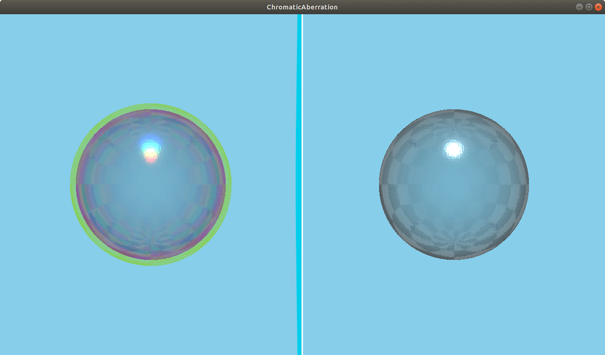

The ChromaticAberration effect simulates an imperfection of optical lenses. In real life, chromatic aberration is an optical phenomenon causing color fringes in high contrast areas. These color fringes are caused by different colors refracting at different angles splitting white light into a spectrum. This is called dispersion.

## Property Documentation

aberrationAmount : real

The strength of the aberration effect. A negative value inverses the effect. The default value is `50`.

focusDepth : real

The distance to the focus plane. The dispersion scales in relation to the distance from this value. The default value is `600`.

maskTexture : TextureInput

A grayscale texture to control the position and strength of the effect. The effect is strongest in white areas, and weakest in black areas. The default is a Texture with source `"maps/white.png"`.

© The Qt Company Ltd  
Licensed under the GNU Free Documentation License, Version 1.3.  
https://doc.qt.io/qt-6.2/qml-qtquick3d-effects-chromaticaberration.html